# ネットワークモチーフ解析

大腸菌の遺伝子制御ネットワークを例にして，ネットワークモチーフ解析を行います。 + ネットワークモチーフを見つける。 + 部分ネットワーク・プロファイルを計算する。

# ネットワークモチーフを見つける

```r
# igraphパッケージの読み込み
library(igraph)
```

### 大腸菌の遺伝子制御ネットワークの読み込み

- `../data/ecoli_regDB5.txt`
- エッジリスト形式
- Salgado H et al. (2006) RegulonDB (version 5.0): Escherichia coli K-12 transcriptional regulatory network, operon organization, and growth conditions. Nucleic Acids Res., 34, pp. D394–D397. https://doi.org/10.1093/nar/gkj156

```r
# エッジリストの読み込み
d <- read.table("../data/ecoli_regDB5.txt")
# グラフオブジェクトの作成（有向ネットワークで読み込む）
g <- simplify(graph_from_data_frame(d,directed=T),remove.multiple=T,remove.loops=T)

# 最大連結成分の取得
cls <- components(g,"weak")
g <- induced_subgraph(g, V(g)$name[cls$membership==which(cls$csize==max(cls$csize))[[1]]])
```

### ネットワークをランダム化するアルゴリズムの読み込み

```r
source("../src/edge_swapping_randomization.R")
```

### 現実のネットワークの3ノードで構成される部分ネットワークの出現頻度を計算

```r
motif_real <- motifs(g,3)
```

### 100個のランダムネットワークの3ノード部分ネットワークの出現頻度を計算

```r
motif_rand <- c()
for(i in 1:100){
  g_rand <- edge_swapping_randomization(g)
  motif_rand <- rbind(motif_rand, motifs(g_rand,3))
}
# データフレームに変換
motif_rand <- as.data.frame(motif_rand)
```

### Zスコアの計算

```r
z_motif <- (motif_real - apply(motif_rand, 2 ,mean)) / apply(motif_rand, 2 ,sd)
# わかりやすいように名前をわり当てる
names(z_motif) <- paste("motif_3_",0:15,sep="")
```

#### 内容の確認

```r
z_motif
```

```
  motif_3_0   motif_3_1   motif_3_2   motif_3_3   motif_3_4   motif_3_5
         NA          NA -12.2527753          NA  -1.9714508  -1.9028379
  motif_3_6   motif_3_7   motif_3_8   motif_3_9  motif_3_10  motif_3_11
 -2.2250968   7.1545928   1.8371117  -5.3093604  -1.8500193  -0.6708204
 motif_3_12  motif_3_13  motif_3_14  motif_3_15
 -1.0267657  12.8732604   1.8837143         NaN
```

`motif_3_7`はネットワークモチーフ（Z>2）であることがわかる。

### 具体的な部分ネットワーク構造を知る

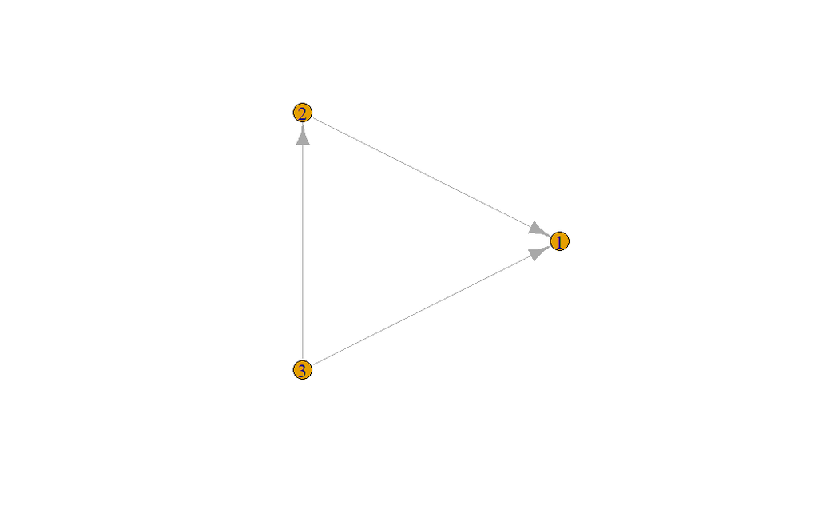

```r
# motif_3_7 の構造は次のようにして知ることができる。
plot(graph.isocreate(3,7), layout=layout.circle)
```

```r
# motif_3_3: Chain
# motif_3_7: Feedforward loop (FFL)
# motif_3_11: Feedback loop (FBL)
```

### P値を計算する（両側検定）

```r
p_motif <- 2 * pnorm(-abs(z_motif))
```

#### 内容の確認

```r
p_motif
```

```
   motif_3_0    motif_3_1    motif_3_2    motif_3_3    motif_3_4    motif_3_5
          NA           NA 1.623435e-34           NA 4.867234e-02 5.706170e-02
   motif_3_6    motif_3_7    motif_3_8    motif_3_9   motif_3_10   motif_3_11
2.607474e-02 8.392168e-13 6.619341e-02 1.100106e-07 6.431077e-02 5.023350e-01
  motif_3_12   motif_3_13   motif_3_14   motif_3_15
3.045308e-01 6.365718e-38 5.960363e-02          NaN
```

### ネットワークモチーフを構成するノード集合を得る。

```r
# 例としてfeedforward loop (motif_3_7)をみてみる。
graph.get.subisomorphisms.vf2(g,graph.isocreate(3,7))
```

[output not shown]

# 部分ネットワーク・プロファイルを計算する

### 有意性プロファイルを計算する

```r
z_motif_na_omit <- c(na.omit(z_motif)) # NAを削除
tsp <- z_motif_na_omit / sqrt(sum(z_motif_na_omit**2))
```

### 結果をプロットする

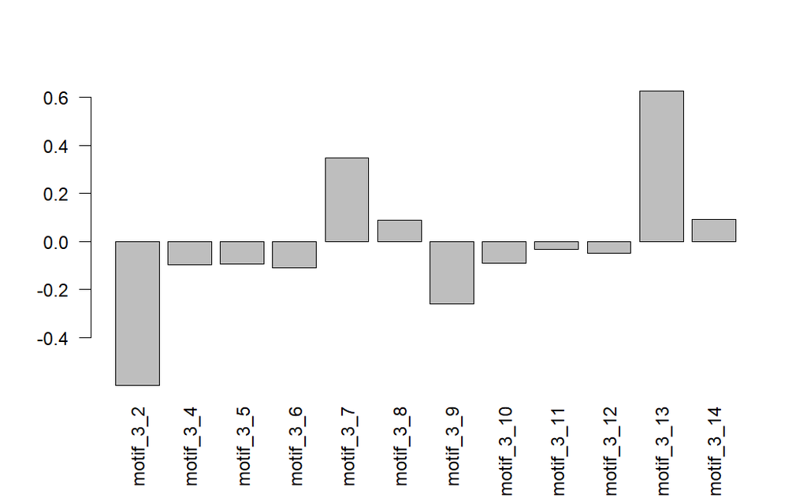

```r
barplot(tsp, las=2)
```

### 部分ネットワーク比率プロファイルの計算

```r
# 相対部分ネットワーク比の計算
tsr_motif <- (motif_real - apply(motif_rand, 2, mean)) / (motif_real + apply(motif_rand, 2, mean) + 4)
# わかrやすいようにモチーフのIDを割り振る
names(tsr_motif) <- paste("motif_3_",0:15,sep="")
# NAを削除する
tsr_motif_na_omit <- c(na.omit(tsr_motif))
# 標準化
tsrp_motif <- tsr_motif_na_omit / sqrt(sum(tsr_motif_na_omit**2))
```

### 結果をプロットする

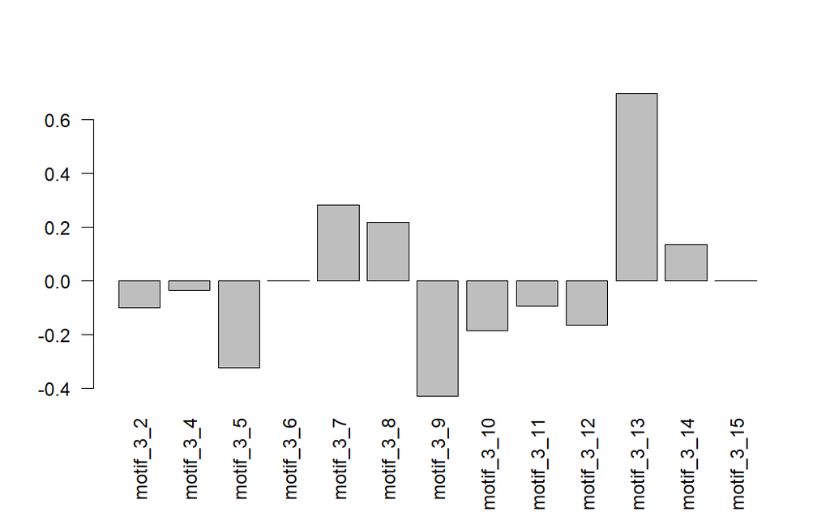

```r
barplot(tsrp_motif, las=2)
```

# やってみよう

- このNotebookを参考にして，生物ネットワークを解析してみよう（`data`に様々ある）。
  - 代謝ネットワークや食物網が良いだろう（有向ネットワークなので）。
- 4ノードのネットワークモチーフを見つけてみよう（計算に時間がかかるの注意）
  - `motifs(g,4)`で計算できる。
- Notebookを参考に自分のデータを解析してみよう。